# Plant Data

Initial visualization and data cleaning

Kevin Schoelz

2019-07-09

# Introduction

I have some experimental data I am looking at, and this is a notebook, to tidy up this data a bit, and do some preliminary visualizations. I have a dataset of some plants that have been inoculated by a virus on a single leaf. The plants are then watched for a few days, and we record the day on which the leaf begins to show signs of infection. There is another dataset out there that I do not have access to that records when the full plant has been infected.

The purpose of this notebook is to plot some of the raw data to get a better idea of what we are looking at, and to generate some cleaned data files, which will be useful for building probabilistic models.

We can start by loading some useful libraries.

```r
library(tidyverse)
library(readxl)
```

We can use the `readxl` package to load the original data. The original data is stored in two separate sheets in an excel file.

```r
# Load data and cache a csv snapshot of the excel file

samples_df <- read_excel("Plant-Data-Tidy.xlsx", sheet = "Survival_cdf.Data") %>%
  write_csv("Survival_cdf.csv")
sampleSizes_df <- read_excel("Plant-Data-Tidy.xlsx", sheet = "Survival.Sample.Sizes") %>%
  write_csv("sample_sizes.csv")

knitr::kable(
  head(samples_df)
)
```

| Trial | Day | Col | XI-K | XI-2 | VIII-A | VIII-B | XI-B | XI-A |
| --- | --- | --- | --- | --- | --- | --- | --- | --- |
| Test 1LL | 7 | 0 | 0 | 0 | 0 | 0 | 0 | 0 |
| Test 1LL | 8 | 2 | 0 | 0 | 2 | 3 | 0 | 2 |
| Test 1LL | 9 | 2 | 2 | 1 | 4 | 7 | 6 | 3 |
| Test 1LL | 10 | 6 | 5 | 3 | 6 | 9 | 6 | 8 |
| Test 1LL | 11 | 10 | 6 | 3 | 7 | 9 | 10 | 12 |
| Test 1LL | 12 | 11 | 7 | 6 | 7 | 9 | 10 | 12 |

```r
knitr::kable(
  head(sampleSizes_df)
)
```

| Trial | Ecotype | Ntot | Nobs | Ncens | ycens |
| --- | --- | --- | --- | --- | --- |
| Test1LL | Col | 18 | 11 | 7 | 14 |
| Test1LL | XI-K | 15 | 7 | 8 | 14 |
| Test1LL | XI-2 | 16 | 6 | 10 | 14 |
| Test1LL | VIII-A | 13 | 7 | 6 | 14 |
| Test1LL | VIII-B | 16 | 9 | 7 | 14 |
| Test1LL | XI-B | 16 | 10 | 6 | 14 |

We want to combine these datasets to get a dataset of $(y_{ng}, \nu_{ng})$ where $y_{ng}$ is the failure day of the $n\text{th}$ plant with genome $g$. $\nu_{ng}$ is the corresponding censoring variable, where $\nu_{ng} = 0$ means that the data was not censored and this was the actual failure day, and $\nu_{ng} = 1$ means the data was censored, the event did not occur and the recorded $y_{ng}$ is just the last day measurments were taken.

We need to extract this data from the raw data tables above.

```r
Sizes_df <- sampleSizes_df %>%
  gather("Ncens", "Nobs", "Ntot",
         key = Size.Type,
         value = Sample.Size)

#df <-
```

# Plots

Lets use some plots to visualize the data. First lets look at how the censoring rate changed from trial to trial for the different genomes.

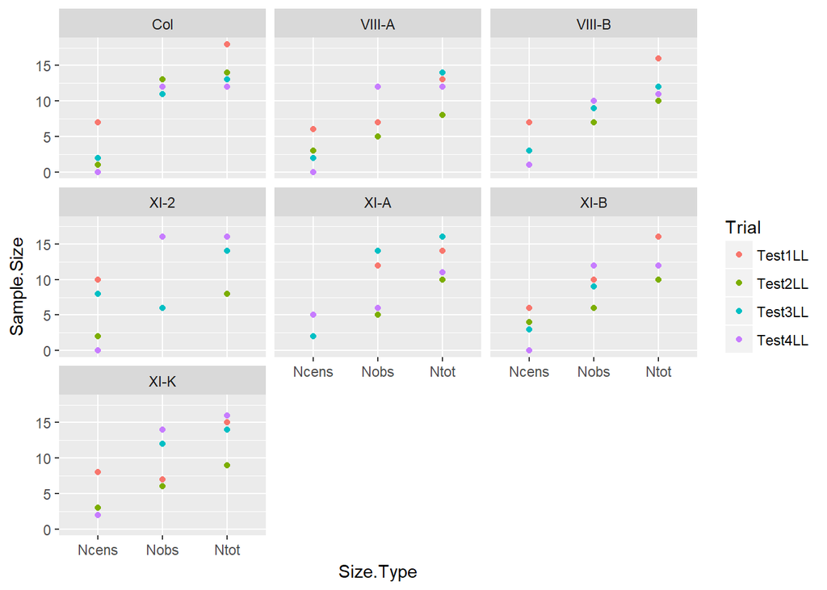

```r
ggplot(data = Sizes_df, aes(x = Size.Type, y=Sample.Size, color = Trial)) +
  geom_point() +
  facet_wrap(~Ecotype)
```